# Lição GitHub n° 5

Construindo gráficos com ggplot2

Barbara Araujo Prates

(18/07/2022)

## Introdução

Lição solicitada pelo professor Ícaro Vidal na disciplina Estatística 2021.2, da Universidade Federal do Recôncavo da Bahia (UFRB).Nesse repositório usaremos 6 tipos de gráficos, dentre eles Gráfico de Pontos, Gráfico de Linhas, Gráfico de Colunas, Histograma, Gráfico de Densidade e Boxplot, com pacote ggplot2, utilizando o dataset, frango_dieta.csv e gordura_corporal.csv.

### Carregando o “tidyverse”

```r
library(tidyverse)
```

### Lendo os dados

```r
dados_gc <- read_csv("dados/gordura_corporal.csv")
dados_gc %>% view()
```

```r
dados_frango <- read_csv("dados/frango_dieta.csv")
dados_frango %>% view()
```

## 1. Gráfico de Pontos

Dado o dataset de gordura corporal, temos o seguinte gráfico pontos de Idade x Peso desenvolvido abaixo:

- dataset(dados_gc)

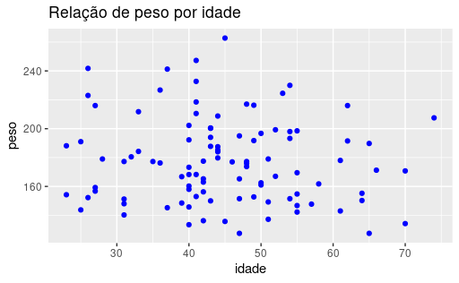

```r
ggplot(dados_gc) +
  aes(x = idade, y = peso) +
  geom_point(size = 1) +
  geom_point(color = "blue") +
  labs(
    title = "Relação de peso por idade"
  )
```

## 2. Gráfico de Linhas;

- dataset(dados_gc)

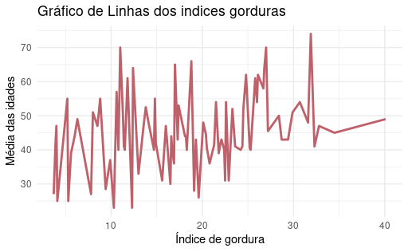

```r
dados_gc %>%
  group_by(indice_gordura) %>%
  summarise(
    media_idade = round(mean(idade), 1)
  ) %>%
  ggplot(aes(x = indice_gordura, y = media_idade, group = 1)) +
  geom_line(color = "#BF616A", size = 1) +
  labs(
    title = "Gráfico de Linhas dos indices gorduras ",
    x = "Índice de gordura",
    y = "Média das idades"
  ) +
  theme_minimal()
```

#### Resposta: o Gráfico de Linhas, mostra que ocorre um aumento considerável com pessoas entre 50 anos ou mais, e tem índices de gordura elevados.

## 3. Gráfico de Colunas (ou de Barras);

- dataset(dados_gc)

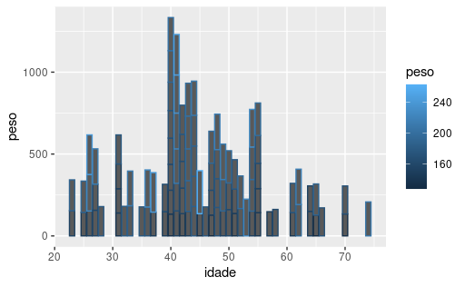

```r
dados_gc %>%
  count(idade, peso) %>%
  ggplot(aes(x = idade, y = peso, color = peso)) +
  geom_col()
```

## 4. Histograma;

- dataset(dados_frango)

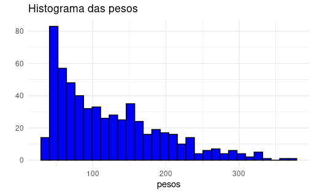

```r
dados_frango %>%
  ggplot() +
  aes(x = peso) +
  geom_histogram(fill = "blue", color = "black") +
  labs(
    title = "Histograma das pesos",
    x = "pesos",
    y = ""
  ) +
  theme_minimal()
```

#### Resposta: o Histograma, mostra que tem um aumento considerável com pesos abaixo de 100, e uma atenuação pra pesos acima desse valor.

## 5. Gráfico de Densidade;

- dataset(dados_gc)

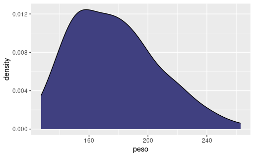

```r
 dados_gc %>%
  ggplot() +
  aes(x = peso ) +
  geom_density(fill = "#404080")
```

```r
NA
```

#### Resposta: o Gráfico de Densidade, mostra que tem um aumento considerável com pessoas de pesos entre 150 á 200.

## 6. Boxplot.

- dataset(dados_frango)

[figure not shown]

```r
dados_frango %>%
  ggplot() +
  aes(x = tempo, y= peso) +
  geom_boxplot(aes(fill = tempo), show.legend = FALSE) +
  scale_fill_viridis_d()
```